# Crime rate falls off before midnight on most days of the week, but stays high later into the night on Fridays and Saturdays

Scott Piraino

## Data and Methods Summary

This is my attempt to visualize data from criminal incidents in Seattle and San Fransisco for the Coursera Data Science at Scale course. I was interested in how different aspects of time such as time of day or day of the week are related to crime, so I have produced several visualizations that are meant to shed light of these relationships. I’ll give a brief explanation of what data I used and how I created the visualizations here, and then I’ll jump into the analysis. I retrieved the drime data for Seattle and San Fransisco from the course GitHub page, which includes the data for 2014 for both cities. I only used incidents that are listed as having occured in the months of June, July and August in 2014. To ensure reproducibility, I created this HTML document using R Markdown. The code used to create this analysis is available on GitHub [here](https://github.com/ScottWPiraino/coursera_dsas_projects/blob/master/crime_project/crime_project.Rmd). In order to reproduce the analysis, ensure that all the required R packages (listed at the end of this section) as well as a working version of R Studio are installed, and then use knitr to generate the HTML document from the R Markdown file. This can be easily done in R Studio by loading the .Rmd file into R Studio and clicking the “Knit HTML” button. I have already done this to produce the HTML document that you are currently viewing, in order to avoid the need for external software. I used http://htmlpreview.github.com/ to make the HTML file on GitHub easily viewable. I produced visualizations with the R package ggplot2, and tweeked the parameters to make the graphs a bit more pretty. I also think one further clarification is helpful. At times in this document I’ll say things like “crime incidence is lower in the early morning compared to the evening”. In all cases, these statements are only intended to apply to this specific dataset. I’m not intending to make any claims about the statistical validity or generalizability of these statements, and they aren’t meant to be causal claims. These statements are meant to be descriptive/exploratory only, and are not meant to have any stronger meaning (i.e. statistical significance, predictive, causal).

Required packages: R Studio and the packages that come with it, RCurl, ggplot2, reshape2

## Visualizations and Analysis

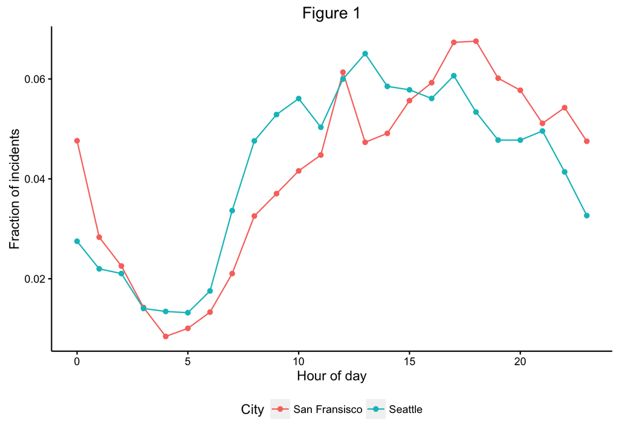

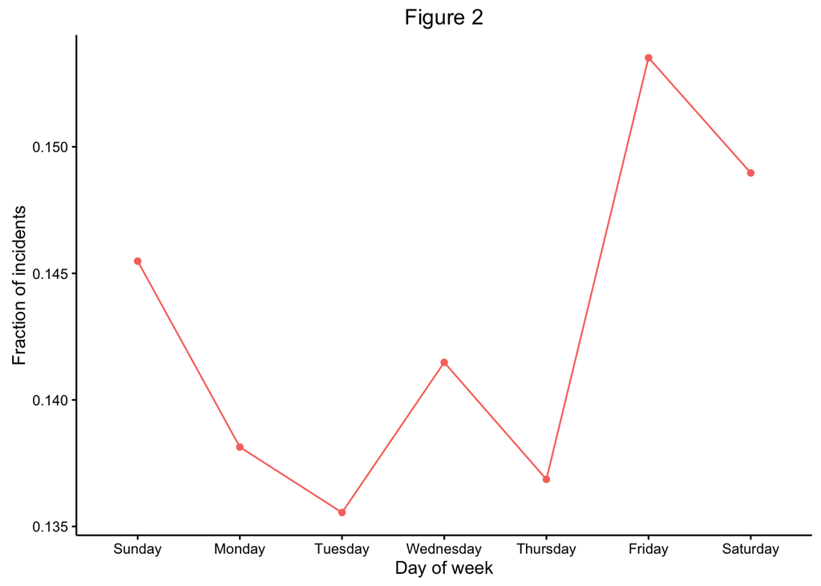

Next, I wanted to look at how crime incidence varies over days of the week. The data for San Fransisco already has the incidents annotated with day of the week, so I performed a similar analysis as above, counting up the number of incidents that occurred at each day of the week and plotting the proportion of incidents on the vertical axis and day of the week on the horizontal, this time using only the San fransisco data. This plot is shown in Figure 2. Friday and Saturday both have higher proportions of incidents compared to the rest of the days, and Sunday has more incidents than Monday - Thursday, but not as much as Friday and Saturday. Wednesday also has a sightly higher number of incidents compared to the other week days.

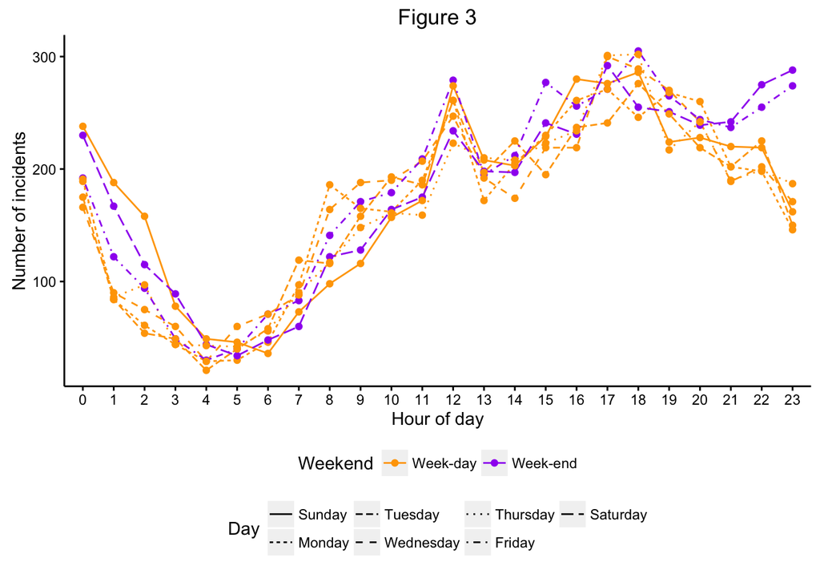

Finally, I wanted to put the two together. Do certain days of the week show a different pattern on the hour to hour level? To assess this possbility, I again used San Fransisco data and counted the number of incidents at each day-hour combination (e.g. hour 0 on Friday, hour 2 on Monday, etc.). In Figure 3 I show essentially the same plot as Figure 1, but this time split up by day of the week. In Figure 3 I plotted absolute number of incidents rather than a proportion because it seems that absolute differences are potentially more meaningful when comparing data from the same city, since factors like total population or differences in enforcement are less worrisome. Each day is plotted using separate line type, and I have also colored the figure so that Friday and Saturday are colored purple, and all other days are colored orange. While most days see the crime incidence fall off on the far right edge of the plot, Friday and Saturday both dip slightly, but then tick back up again so that for these two days specifically crime incidence stays high approaching midnight, in contrast to the other days of the week.